# Introdução ao Tidyverse

Raul Lima e parceiros

08 de Outubro de 2019

# O que é tidyverse?

- Hadley Wickham

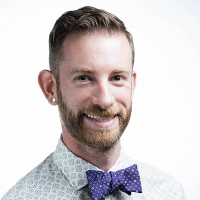

- Tidyverse
  - readr
  - tidyr
  - dplyr
  - ggplot
  - forcats

# Readr

- Qual seu diferencial?

O readr pacote foi desenvolvido para lidar rapidamente com a leitura em grandes arquivos planos.

O pacote fornece substituições para funções como read.table() e read.csv(). As funções análogas em readr são read_table() e read_csv(). Essas funções são frequentemente muito mais rápidas do que seus análogos R e fornecem alguns outros recursos interessantes.

```r
#Utilizando função nativa
read.csv("fullbusiness.csv")
#Utilizando função do pacote readr
library(readr)
read_csv("fullbusiness.csv")
```

- Arquivo separado por " , "

```
read_csv()
```

- Arquivo separado por " ; "

```
read_csv2()
```

```
read_tsv()
```

- Arquico com delimitações

```
read_delim()
```

# Exercícios

- Importe o banco de dados fullbusiness
- Importe o banco de dados titanic
- Importe o banco de dados urine

# Complemento

- Dados do tipo Excel (.xls/.xlsx)

```
install.packages("readxl")
library(readxl)
read_excel()
read_xls()
read_xlsx()
```

- Importar banco de dados melanoma

```r
library(readxl)
read_xlsx("melanoma.xlsx")
```

# dplyr

- `select()`
- `filter()`
- `group_by()` e `summarise()`
- `arrange()`

# `select()`

Função que seleciona ou retira determinada variável do seu data frame (coluna, campo, feature, …).

Selecionando variáveis:

```r
library(dplyr)
fullbusiness <- read_delim("fullbusiness.csv", delim= ",")
#head(fullbusiness)
renda_zona <- fullbusiness %>% select(Zone, Income)
#head(renda_zona)
```

Retirando variáveis:

```r
sem_spam <- fullbusiness %>% select(-SPAM)
#head(sem_spam)
```

# `filter()`

Função que cria condições para selecionar determinado tipo de variável.

Utilizando o banco de dados fullbusiness pedemos separar pela categoria da variavel level.

```r
table(fullbusiness$Level)
```

```
##
##    Big Medium  Small
##   2905  25795  56596
```

```r
medium <- fullbusiness %>% filter(Level == "Medium")
table(medium$Level)
```

```
##
## Medium
##  25795
```

# `group_by()` e `summarise()`

São operadores que trabalham na agregação dos dados, ou seja, é feito um resumo dos dados para cada grupo.

O `group_by()` separa os grupos que se deseja selecionar, já o `summarise()` faz o resumo dos dados para cada grupo.

```r
library(TeachingSampling)
data("BigLucy")
#head(BigLucy)

exemplo <- BigLucy %>% filter(Years >= 10) %>% group_by(Level) %>%
summarise(total_empresas = n(), media_renda = sum(Income), media_taxas = mean(Taxes))
exemplo
```

```
## # A tibble: 3 x 4
##   Level  total_empresas media_renda media_taxas
##   <fct>           <int>       <int>       <dbl>
## 1 Big              2349     2933231       75.3
## 2 Medium          20998    13888369       22.1
## 3 Small           46074    12984694        3.88
```

# `arrange()`

Serve para organizar os dados em sua ordenação.

```r
fullbusiness %>% select(Level, Employees, Income) %>%
group_by(Level) %>%
summarise(mean_employees = mean(Employees), mean_income = mean(Income)) %>% arrange()
```

```
## # A tibble: 3 x 3
##   Level  mean_employees mean_income
##   <chr>           <dbl>       <dbl>
## 1 Big             138.        1249.
## 2 Medium           80.9        661.
## 3 Small            51.3        282.
```

# Exercício

- Utilizando o banco de dados `"flights"` do pacote `nycflights13`, selecione as variáveis mês, `arr_delay` e `arr_delay` para fazer uma tabela com a média dos atrasos dos meses ordenadas pela média dos atrasos das partidas.

Dica: usar `mean(, na.rm = TRUE)`

# Solução

```r
library(nycflights13)
data("flights")
#str(flights)
flights %>% select(month, arr_delay, dep_delay) %>% group_by(month) %>%
  summarise(dep_delay_mean = mean(dep_delay, na.rm =  TRUE),arr_delay_mean = mean(arr_delay, na.rm = TRUE)) %>%
  arrange()
```

```
## # A tibble: 12 x 3
##    month dep_delay_mean arr_delay_mean
##    <int>          <dbl>          <dbl>
##  1     1          10.0           6.13
##  2     2          10.8           5.61
##  3     3          13.2           5.81
##  4     4          13.9          11.2
##  5     5          13.0           3.52
##  6     6          20.8          16.5
##  7     7          21.7          16.7
##  8     8          12.6           6.04
##  9     9           6.72         -4.02
## 10    10           6.24         -0.167
## 11    11           5.44          0.461
## 12    12          16.6          14.9
```

# Tidyr

- `gather()`
- `spread()`
- `separate()`
- `unite()`

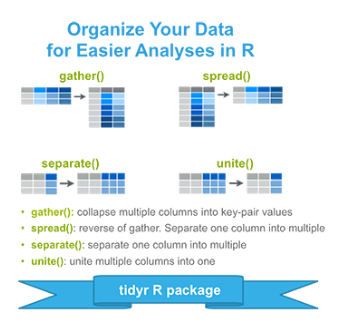

# `gather()`

Utilizada para agrupar duas ou mais colunas e seus respectivos valores em pares, assim o resultado após o agrupamento é sempre duas colunas

Nesse comando o primeiro informa-se a coluna que aguarda as variáveis das linhas, segundo informa-se os valores de cada linhas.

```r
data("USArrests")
head(USArrests)
```

```
##            Murder Assault UrbanPop Rape
## Alabama      13.2     236       58 21.2
## Alaska       10.0     263       48 44.5
## Arizona       8.1     294       80 31.0
## Arkansas      8.8     190       50 19.5
## California    9.0     276       91 40.6
## Colorado      7.9     204       78 38.7
```

```r
USArrests$State <- rownames(USArrests)
us_long <- USArrests %>% gather(key =  "tipo_crime", value = "valor", -State)
head( us_long)
```

```
##        State tipo_crime valor
## 1    Alabama     Murder  13.2
## 2     Alaska     Murder  10.0
## 3    Arizona     Murder   8.1
## 4   Arkansas     Murder   8.8
## 5 California     Murder   9.0
## 6   Colorado     Murder   7.9
```

# `spread()`

É o oposto do comando anterior, transforma as variavei de uma coluna em linhas.

```r
head(table2)
```

```
## # A tibble: 6 x 4
##   country      year type           count
##   <chr>       <int> <chr>          <int>
## 1 Afghanistan  1999 cases            745
## 2 Afghanistan  1999 population  19987071
## 3 Afghanistan  2000 cases           2666
## 4 Afghanistan  2000 population  20595360
## 5 Brazil       1999 cases          37737
## 6 Brazil       1999 population 172006362
```

```r
table2 %>% spread(key = type, value =  count)
```

```
## # A tibble: 6 x 4
##   country      year  cases population
##   <chr>       <int>  <int>      <int>
## 1 Afghanistan  1999    745   19987071
## 2 Afghanistan  2000   2666   20595360
## 3 Brazil       1999  37737  172006362
## 4 Brazil       2000  80488  174504898
## 5 China        1999 212258 1272915272
## 6 China        2000 213766 1280428583
```

# `separate()`

Usado para separar duas variáveis que estão na mesma coluna.

```r
table3[1:3,]
```

```
## # A tibble: 3 x 3
##   country      year rate
##   <chr>       <int> <chr>
## 1 Afghanistan  1999 745/19987071
## 2 Afghanistan  2000 2666/20595360
## 3 Brazil       1999 37737/172006362
```

```r
dados_separado <- table3 %>% separate(rate, into = c("cases", "population"), sep = "/")
dados_separado[1:3,]
```

```
## # A tibble: 3 x 4
##   country      year cases population
##   <chr>       <int> <chr> <chr>
## 1 Afghanistan  1999 745   19987071
## 2 Afghanistan  2000 2666  20595360
## 3 Brazil       1999 37737 172006362
```

# `unite()`

Sendo o oposto da função anterior, ela junta duas colunas e as tranforma em uma.

```r
table2 %>% unite(type_year, type, year) %>% spread(key = type_year, value = count, sep = '_')
```

```
## # A tibble: 3 x 5
##   country type_year_cases… type_year_cases… type_year_popul…
##   <chr>              <int>            <int>            <int>
## 1 Afghan…              745             2666         19987071
## 2 Brazil             37737            80488        172006362
## 3 China             212258           213766       1272915272
## # … with 1 more variable: type_year_population_2000 <int>
```

# Exercício

Utilizando o banco de dados `sleep` faça uma nova tabela tomando como base a variavel `group`.

# Solução

```r
sleep %>% spread(key = group, value=extra)
```

```
##    ID    1    2
## 1   1  0.7  1.9
## 2   2 -1.6  0.8
## 3   3 -0.2  1.1
## 4   4 -1.2  0.1
## 5   5 -0.1 -0.1
## 6   6  3.4  4.4
## 7   7  3.7  5.5
## 8   8  0.8  1.6
## 9   9  0.0  4.6
## 10 10  2.0  3.4
```

# ggplot

O ggplot2 é mais do que um pacote para fazer gráficos; ele é a implementação da gramática dos gráficos em camadas no R.

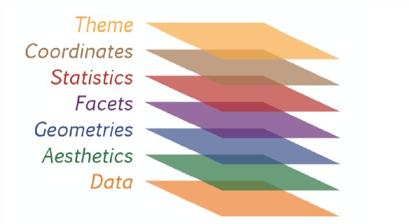

# forcats

Grande parte da frustração associada ao uso de fatores no R existe por conta da falta de algumas ferramentas úteis no pacote base. Para resolver esse o problema, Hadley Wickham ajudou a comunidade R desenvolvendo o pacote forcats(for categorial variables), que implementa algumas dessas ferramentas.

As principais funções do forcats servem para alterar a ordem e modificar os níveis de um fator.

- Fatores

```r
library(forcats)
```

```r
melanoma <- read_xlsx("melanoma.xlsx")
str(melanoma$ulcer) # Perceba aqui, que as variáveis são númericas
```

```
##  num [1:205] 1 0 0 0 1 1 1 1 1 1 ...
```

```r
lvls_revalue(factor(melanoma$ulcer),c("ausente","presente"))
```

```
##   [1] presente ausente  ausente  ausente  presente presente presente
##   [8] presente presente presente presente presente presente presente
##  [15] presente presente presente presente presente presente presente
##  [22] presente presente presente presente ausente  presente presente
##  [29] ausente  ausente  ausente  presente presente presente ausente
##  [36] presente presente presente presente presente presente presente
##  [43] presente ausente  ausente  ausente  presente presente ausente
##  [50] ausente  presente presente ausente  ausente  ausente  ausente
##  [57] ausente  ausente  ausente  presente ausente  ausente  ausente
##  [64] ausente  ausente  ausente  ausente  ausente  presente ausente
##  [71] ausente  ausente  ausente  ausente  presente presente ausente
##  [78] presente ausente  presente ausente  ausente  presente ausente
##  [85] ausente  presente presente ausente  presente ausente  ausente
##  [92] ausente  ausente  presente presente ausente  ausente  presente
##  [99] ausente  ausente  ausente  presente ausente  ausente  presente
```

[output cut: 16 more lines]

# Exercícios

- Modifique os fatores das colunas ‘sex’ e ‘status’ do banco de dados melanoma
- Modifique os fatores das colunas ‘age’ e ‘survived’ do banco de dados titanic

# resolução

É utilizado o comando `factor()` pois a coluna não está no tipo fator, quando quiser saber o tipo que é cada coluna utilize o comando `str()`.

```r
melanoma$sex <- lvls_revalue(factor(melanoma$sex), c("female", "male"))
melanoma$status <- lvls_revalue(factor(melanoma$status),
                                c("died", "alive", "dead urelated"))
head(melanoma)
```

```
## # A tibble: 6 x 7
##    time status        sex      age  year thickness ulcer
##   <dbl> <fct>         <fct>  <dbl> <dbl>     <dbl> <dbl>
## 1    10 dead urelated male      76  1972      6.76     1
## 2    30 dead urelated male      56  1968      0.65     0
## 3    35 alive         male      41  1977      1.34     0
## 4    99 dead urelated female    71  1968      2.9      0
## 5   185 died          male      52  1965     12.1      1
## 6   204 died          male      28  1971      4.84     1
```